# A or CNAME?

Thomas Peterson

21 November 2018

# Introduction

In this notebook we analyse each domain in the Alex top 1 million domain list, understanding the record type for `www` for every domain, and perform basic analysis on the CNAME records as well as authoritive name servers.

## Considerations when interpretting this data

All queries in the supplied data set were captured over approximately two days between November 12<sup>th</sup> and 13<sup>th</sup> 2018, and were performed from a host within [AS2818](https://www.peeringdb.com/asn/2818), and thus answers may be influenced due to EDNS Client Subnet.

# Record type breakdown

Each one of the domains was queried for a `www` subdomain, either as A or CNAME, in addition to a query for name servers for the domain.

- `NXDOMAIN`: The domain exists and has delegated name servers, but does not have a record for `www.`
- `SERVFAIL`: The domain may or may not exist, and does not have delegated nameservers
- `CNAME`: A CNAME record was returned for `www.`
- `DNAME`: A DNAME record was returned for `www.`
- `A`: An A record was returned for `www.`

The `NXDOMAIN` largely exist due to them being subdomains themselves, or domains not intended for users to put into address bars in browsers (e.g. `bp.blogspot.com`) but used for serving other content. There are also several that do not intended on serving a web page, but are linked to (e.g. `redd.it`).

```r
value   = c()
percent = c()
record  = c()

totalServfail <- recordData %>% filter(class == "") %>% summarize(count=n())
totalNxDomain <- recordData %>% filter(class != "" & class != "IN") %>% summarize(count=n())

totals <- recordData %>% group_by(recordType) %>% filter(class == "IN") %>% summarize(count=n())

for(i in 1:nrow(totals)){
  type    <- totals[i,]
  value   <- c(value, type$count)
  percent <- c(percent, type$count / 10000)
  record  <- c(record, type$recordType)
}

# NXDOMAIN values
value   <- c(value, as.numeric(totalNxDomain$count))
percent <- c(percent, as.numeric(totalNxDomain$count) / 10000)
record  <- c(record, "NXDOMAIN")

# SERVFAIL values
value   <- c(value, as.numeric(totalServfail$count))
percent <- c(percent, as.numeric(totalServfail$count) / 10000)
record  <- c(record, "SERVFAIL")

recordTotals <- data.frame(
  record  = record,
  value   = value,
  percent = percent
)
```

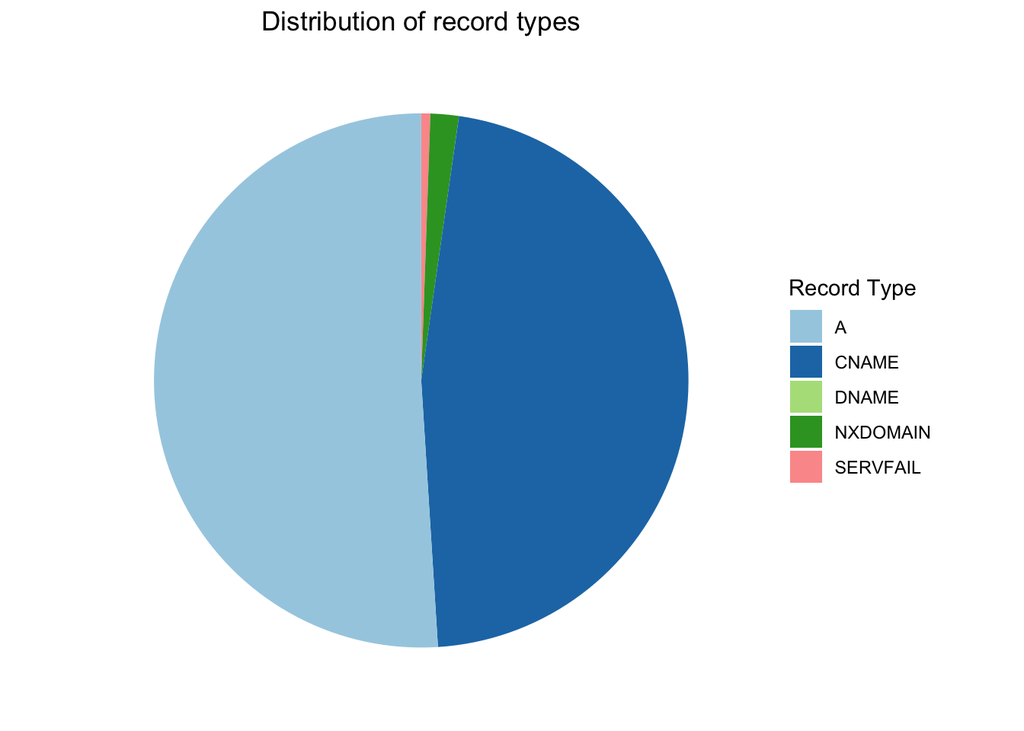

```r
recordTypePlot <- ggplot(recordTotals, aes(x="", y=value, fill=record))+
geom_bar(width=1, stat="identity")
recordTypePlot +
  coord_polar("y", start=0) +
  scale_fill_brewer(palette="Paired", name="Record Type") +
  theme_minimal() +
  labs(title="Distribution of record types") +
  theme(
    axis.title.x = element_blank(),
    axis.title.y = element_blank(),
    axis.ticks   = element_blank(),
    axis.text    = element_blank(),
    panel.border = element_blank(),
    panel.grid   = element_blank(),
    plot.title=element_text(hjust = 0.5)
  )
```

```r
recordTable <- data.frame(recordTotals)

recordTable$percent <- apply(recordTable, 1, function(x){
  x[[3]] = sprintf("%.2f%%", as.numeric(x[[3]]))
})
recordTable$value <- NULL
colnames(recordTable) <- c("Record Type", "Percentage")
```

```r
kable(recordTable)
```

| Record Type | Percentage |
| --- | --- |
| A | 51.00% |
| CNAME | 46.74% |
| DNAME | 0.00% |
| NXDOMAIN | 1.71% |
| SERVFAIL | 0.55% |

## CNAME Usage

```r
# FIXME: this could be done better
cnameList <- list(

  ### CDNs
  c("Content Delivery Network", "Akamai", "edgekey.net."),
  c("Content Delivery Network", "Akamai", "edgesuite.net."),
  c("Content Delivery Network", "Akamai", "akadns.net."),

  c("Content Delivery Network", "Fastly", "fastly.net."),
  c("Content Delivery Network", "Fastly", "fastlylb.net."),
  c("Content Delivery Network", "CloudFlare", "cloudflare.net."),
  c("Content Delivery Network", "Amazon Web Services", "cloudfront.net."),
  #c("Content Delivery Network", "Cedexis", "cedexis.net."),
  #c("Content Delivery Network", "FastCDN", "fastcdn.com."),
  #c("Content Delivery Network", "J-Stream", "stream.ne.jp."),
  c("Content Delivery Network", "Incapsula", "incapdns.net."),
  #c("Content Delivery Network", "Azion", "azioncdn.net."),
  #c("Content Delivery Network", "Fasterized", "fasterized.com."),
  c("Content Delivery Network", "Azure", "azureedge.net."),
  #c("Content Delivery Network", "Distil", "distil.us."),

  ### Hosting Providers
  c("Hosting Provider", "Amazon Web Services", "elb.amazonaws.com."),
  c("Hosting Provider", "Amazon Web Services", "elasticbeanstalk.com."),
  c("Hosting Provider", "Google", "ghs.googlehosted.com."),

  c("Hosting Provider", "Azure", "azurewebsites.net."),
  c("Hosting Provider", "Azure", "cloudapp.net."),

  c("Hosting Provider", "Heroku", "herokussl.com."),
  c("Hosting Provider", "Heroku", "herokudns.com."),

  ### Content Providers
  c("Content Provider", "Google", "googleusercontent.com."),
  c("Content Provider", "Google", "ghs.google.com."),
  c("Content Provider", "Squarespace", "squarespace.com."),
  c("Content Provider", "Shopify", "shopify.com."),
  c("Content Provider", "Shopify", "shopifycloud.com."),
  c("Content Provider", "HubSpot", "hubspot.net.")
)

hostingTypes     <- c()
hostingProviders <- c()
hostingDomains   <- c()
totalHosts       <- c()

for(provider in cnameList){
  totalHost <- recordData %>%
                filter(str_detect(answer, sprintf("%s$", provider[[3]]))) %>%
                summarize(count=n())
  hostingTypes     <- c(hostingTypes, provider[[1]])
  hostingProviders <- c(hostingProviders, provider[[2]])
  hostingDomains   <- c(hostingDomains, provider[[3]])
  totalHosts       <- c(totalHosts, totalHost$count)
}

cnameUsage <- data.frame(
  type     = hostingTypes,
  provider = hostingProviders,
  domain   = hostingDomains,
  total    = totalHosts
)

# Total records from providers we know about
totalFoundCnames <- colSums(Filter(is.numeric, cnameUsage))
foundCnamesPercentage <-
  totalFoundCnames[[1]] / (recordTotals %>% filter(record == "CNAME"))$value * 100

# Total that point www back at apex
wwwToApexTotal <- recordData %>%
  filter(answer == sprintf("%s.", domain)) %>%
  summarize(count=n())

wwwToApexPercentage <-
   wwwToApexTotal[[1]] / (recordTotals %>% filter(record == "CNAME"))$value * 100
```

For the records that return CNAMEs, **88939** (or 19.03% of total CNAME records) records point directly at addresses that reveal information about hosting providers such as CDNs, cloud providers, or other Software as a Service offerings. **299924** (64.17% of total CNAME records) of records pointed users back to apex - i.e. www.example.com. responds with a CNAME to example.com.

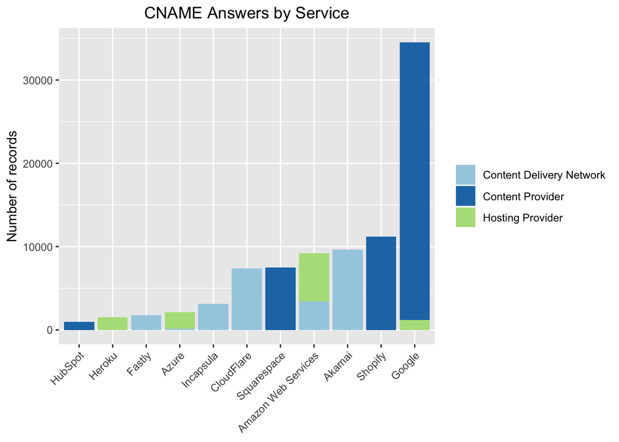

```r
cnamePlot <- ggplot(cnameUsage, aes(x=reorder(provider,total, sum), group=provider, y=total, fill=type))
cnamePlot +
  geom_bar(stat="identity") +
  scale_fill_brewer(palette="Paired", name="") +
  labs(
    title="CNAME Answers by Service",
    y="Number of records"
  ) +
  theme(
    axis.text.x=element_text(angle=45, hjust=1),
    axis.title.x=element_blank(),
    plot.title=element_text(hjust=0.5)
  )
```

The largest representation of hosts is from Google, mostly comprising of Blogspot addresses as well as a small percentage of Google Code sites.

## DNAME Usage

```r
dnameTotal <- recordData %>% filter(recordType == "DNAME") %>% summarize(count=n())
dnameRecords <- recordData %>%
  select(domain, recordType, answer) %>%
  filter(recordType == "DNAME")

dnameRecords$recordType <- NULL
colnames(dnameRecords) <- c("Domain", "Answer")
```

```r
kable(dnameRecords)
```

| Domain | Answer |
| --- | --- |
| lancaster.ac.uk | lancs.ac.uk. |
| gobierno.pr | pr.gov. |
| 7kanal.co.il | israel7.ru. |
| yonhapnewstv.co.kr | news-y.co.kr. |
| cbnu.ac.kr | chungbuk.ac.kr. |
| dl-one2up.com | dname.th7.swiftserve.com. |
| hochschule-bochum.de | hs-bochum.de. |
| uos.de | uni-osnabrueck.de. |
| multiplay.com | multiplay.co.uk. |
| upb.de | uni-paderborn.de. |
| nationaldrugstrategy.gov.au | health.gov.au. |
| fh-worms.de | HS-Worms.DE. |
| pbefcu.com | pbcreditunion.com. |
| cancerscreening.gov.au | health.gov.au. |
| gidaje.ng | sheltered-plum-jrup4durxogpausujdn1h0pq.herokudns.com. |
| ianyang.ac.kr | yeonsung.ac.kr. |
| alcohol.gov.au | health.gov.au. |

# Nameserver Usage

```r
nameServerList <- list(
  # Unlike CNAMEs, we have to be much looser on the matching as some providers use multiple TLDs
  # List taken from https://en.wikipedia.org/wiki/List_of_managed_DNS_providers

  # DNS Providers
  c("DNS Provider", "Dyn", "dynect."),
  c("DNS Provider", "NS1", "nsone.net."),
  c("DNS Provider", "Verisign", "verisigndns"),
  c("DNS Provider", "UltraDNS", "ultradns."),
  c("DNS Provider", "DNSimple", "dnsimple.com."),
  c("DNS Provider", "ClouDNS", "cloudns.net."),
  #c("DNS Provider", "CloudfloorDNS", "cloudfloordns."),
  c("DNS Provider", "DNS Made Easy", "dnsmadeeasy.com"),
  c("DNS Provider", "EasyDNS", "easydns."),
  #c("DNS Provider", "No-IP", "no-ip.com."),
  #c("DNS Provider", "Constellix", "constellix."),

  # Registrars
  c("Registrar", "Namecheap", "registrar-servers.com."),
  c("Registrar", "Gandi", "gandi.net."),
  c("Registrar", "Godaddy", "domaincontrol.com."),
  c("Registrar", "123-reg", "123-reg.co.uk."),
  c("Registrar", "eNom", "name-services.com."),

  # Hosting Providers
  c("Hosting Provider", "AWS Route53", ".awsdns-"),
  c("Hosting Provider", "Azure", "azure-dns"),
  c("Hosting Provider", "Google", "googledomains.com"),
  #c("Hosting Provider", "Alibaba", "alibabadns.com."),
  c("Hosting Provider", "Linode", "linode.com."),
  c("Hosting Provider", "DigitalOcean", "digitalocean.com."),
  c("Hosting Provider", "Godaddy", "secureserver.net."),
  c("Hosting Provider", "OVH", "ovh.net."),

  # Content Delivery Networks
  c("Content Delivery Network", "CloudFlare", "cloudflare.com."),
  c("Content Delivery Network", "Akamai", "akam.net"),

  # Content Providers
  #c("Content Provider", "Wordpress", "wordpress.com"),
  c("Content Provider", "Google", "google.com."),
  c("Content Provider", "Squarespace", "squarespacedns.com.")
)

nsHostingTypes <- c()
nsProviders    <- c()
nsDomains      <- c()
nsTotalHosts   <- c()

for(provider in nameServerList){
  totalHost <- recordData %>%
                filter_at(vars(contains("ns")), any_vars(str_detect(. , provider[[3]]))) %>%
                summarize(count=n())
  nsHostingTypes <- c(nsHostingTypes, provider[[1]])
  nsProviders    <- c(nsProviders, provider[[2]])
  nsDomains      <- c(nsDomains, provider[[3]])
  nsTotalHosts   <- c(nsTotalHosts, totalHost$count)
}

nameServerUsage <- data.frame(
  type     = nsHostingTypes,
  provider = nsProviders,
  domain   = nsDomains,
  total    = nsTotalHosts
)

totalFoundNameServers <- colSums(Filter(is.numeric, nameServerUsage))
```

Out of all the records that did return name servers, **323751** name servers references were matched across the dataset.

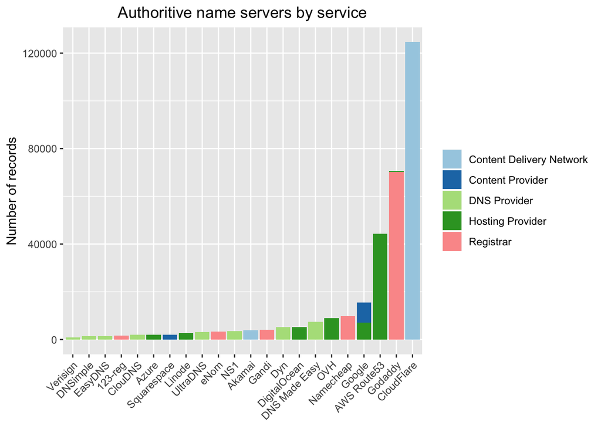

```r
nsPlot <- ggplot(nameServerUsage, aes(x=reorder(provider,total, sum), group=provider, y=total, fill=type))
nsPlot +
  geom_bar(stat="identity") +
  scale_fill_brewer(palette="Paired", name="") +
  labs(
    title="Authoritive name servers by service",
    y="Number of records"
  ) +
  theme(
    axis.text.x=element_text(angle=45, hjust=1),
    axis.title.x=element_blank(),
    plot.title=element_text(hjust=0.5)
  )
```